```r
####################################################
### R code to reproduce the submitted manuscript
###
### "hdMTD:
###  An R Package for High-Dimensional Mixture Transition
###  Distribution Models"
###
### Authors: Maiara Gripp, Giulio Iacobelli, Guilherme Ost, Daniel Y. Takahashi
### Date: October 2025
####################################################

# Required packages:
# install.packages(c("hdMTD", "dplyr", "ggplot2","lubridate", "purrr", "tidyr", "future", "future.apply"))

## Load packages
library("hdMTD")
library("dplyr")
library("ggplot2")
library("lubridate")
library("purrr")
library("tidyr")
library("future")
library("future.apply")
# Set recompute_all = TRUE to override all pre-computed results (not recommended)
recompute_all <- TRUE

# Set save_precomputed = TRUE to store results in their corresponding RDS file.
save_precomputed <- FALSE
```

```r
## Notes on pre-computed time-consuming computations:
```

```r
# All procedures that take longer than ~2 minutes were pre-computed and stored in
# hdMTD_outputs.rds, simulated_data.rds or results_sequential_selection.rds.
# To recompute any of them, set the corresponding `recompute <- TRUE` block to
# activate the code. For each recompute block, an estimated runtime (on i7-1255U
# 10 cores) is provided. Note that if the corresponding RDS file is not available,
# the data will be recomputed even if `recompute` is set to FALSE.

# One procedure takes much longer than the others: the check that the
# estimation error converges to the minimal error over 100 samples in section 5.3.
# The average runtime per sample is about 90 minutes.
# This procedure was run in parallel using 6 workers, and took roughly 1 day to
# complete. The total runtime depends on the number of workers: for W workers,
# the expected runtime is approximately ceiling(100 / W) * 90 minutes. Adjust the
# number of workers (n_workers at section 5.3) accordingly before recomputing
# this step.

# Diagnostic: check if/which pre-computed RDS files are missing
required_rds <- c(
  "hdMTD_outputs.rds",               # Section 5: hdMTD examples
  "simulated_data.rds",              # Section 5.3: simulations
  "results_sequential_selection.rds" # Section 5.4: FS sequential selection (nu analysis)
)
missing_rds <- required_rds[!file.exists(required_rds)]
# Warns users if recompute_all = FALSE and there are missing RDS files.
if (!recompute_all && length(missing_rds) > 0) {
  message(
    paste0(
      "\nThe following pre-computed RDS files are missing:\n  -> ",
      paste(missing_rds, collapse = "\n  -> "),
      "\n\nTherefore, these results will be recomputed automatically when\n",
      "needed even if `recompute = FALSE` inside that block.\n",
      "This will significantly increase processing time.\n",
      "To avoid recomputation, provide the missing RDS files.\n"
    )
  )
}
```

```r
# Load pre-computed hdMTD_outputs if available and recompute_all = FALSE.
use_precomputed_hdMTD_outputs <- !recompute_all && file.exists("hdMTD_outputs.rds")
if (use_precomputed_hdMTD_outputs) {
  message("Using pre-computed results from 'hdMTD_outputs.rds'.")
  precomputed <- readRDS(file = "hdMTD_outputs.rds")
} else {
  message("Pre-computed results not available or recompute_all = TRUE.")
  precomputed <- list()
}
```

```
## Pre-computed results not available or recompute_all = TRUE.
```

## Section 5: Using hdMTD

### 5.1 Data generation

1. Generate MTD model:

Parameters: \(\Lambda = \{-30,-15,-1\}\), \(\mathcal{A} = \{0,1\}\), \(\lambda_0= \{0.01\}\), \(\lambda_{-1} = 0.39\), \(\lambda_{-15} = \lambda_{-30} = 0.3\), \(p_0(0)=p_0(1)=0.5\), and transition matrices \(p_j\), \(j\in\Lambda\), sampled uniformly.

```r
set.seed(11)
Lambda <- c(1, 15, 30)
A <- c(0, 1)
lam0 <- 0.01
lamj <- c(0.39, 0.3, 0.3)
p0 <- c(0.5, 0.5)
MTD <- MTDmodel(Lambda = Lambda, A = A, lam0 = lam0, lamj = lamj, p0 = p0)
summary(MTD)
```

```
## Mixture Transition Distribution (MTD) model
##
## Call:
## MTDmodel(Lambda = Lambda, A = A, lam0 = lam0, lamj = lamj, p0 = p0)
##
## Relevant lags: -1, -15, -30
## State space: 0, 1
##
## lambdas (weights):
##   lam0  lam-1 lam-15 lam-30
##   0.01   0.39   0.30   0.30
##
## Independent distribution p0:
## p0(0) p0(1)
##   0.5   0.5
##
## Transition matrices pj (one per lag):
##
##  pj for lag j = -1:
##            0         1
## 0 0.35190318 0.6480968
## 1 0.03558321 0.9644168
##
##  pj for lag j = -15:
##           0         1
## 0 0.4278830 0.5721170
## 1 0.7670555 0.2329445
##
##  pj for lag j = -30:
##           0         1
## 0 0.8341439 0.1658561
## 1 0.2184814 0.7815186
##
## Transition matrix P: 8 x 2
## - Preview of first rows of P:
##             0         1
## 000 0.5208503 0.4791497
## 001 0.3974855 0.6025145
## 010 0.6226020 0.3773980
## 011 0.4992372 0.5007628
## 100 0.3361516 0.6638484
## 101 0.2127868 0.7872132
##
## Reading guide for P:
## Rows list past contexts from oldest to newest, matching lags (-30, -15, -1).
```

2. Sample from the invariant distribution

```r
X <- perfectSample(MTD, N = 1000)
```

### 5.2 Estimation

3. Estimate relevant lags using FS method

```r
hdMTD_FS(X, d = 40, l = 4)
```

```
## [1] 30 15  1 27
```

```r
FS <- hdMTD(X, d = 40, method = "FS", l = 4)
S(FS); summary(FS)
```

```
## [1] 30 15  1 27
```

```
## hdMTD lag selection
##
## Call:
## hdMTD(X = X, d = 40, method = "FS", l = 4)
##
## Method: FS
## Order upper bound (d): 40
## Selected S set: 30, 15, 1, 27
##
## Relevant lag set estimated by FS method : -30, -15, -1, -27
```

4. Estimate relevant lags using BIC method

```r
recompute <- FALSE
recompute <- recompute || (!use_precomputed_hdMTD_outputs)
```

```r
if (recompute) {
  message("Recomputing...")
  BIC_d40_l4 <- hdMTD_BIC(X, d = 40, minl = 4, maxl = 4) #takes ~30min.
  precomputed$BIC_d40_l4 <- BIC_d40_l4
} else {
  message("Using pre-computed data.")
  BIC_d40_l4 <- precomputed$BIC_d40_l4
}
```

```
## Recomputing...
```

```r
print(BIC_d40_l4)
```

```
## [1]  1 15 17 30
```

Custom subset S

```r
hdMTD_BIC(X, d = 40,
          S = c(1, 5, 10, 15, 17, 20, 27, 30, 35, 40),
          minl = 4, maxl = 4)
```

```
## [1]  1 15 17 30
```

Varying number of lags to be selected

```r
hdMTD_BIC(X, d = 40,
          S = c(1, 5, 10, 15, 17, 20, 27, 30, 35, 40),
          minl = 1, maxl = 4)
```

```
## [1] 30
```

With BIC values by number of lags

```r
hdMTD_BIC(X, d = 40,
          S = c(1, 5, 10, 15, 17, 20, 27, 30, 35, 40),
          minl = 1, maxl = 4,
          byl = TRUE, BICvalue = TRUE)
```

```
##           30        15,30      1,15,30   1,15,17,30 smallest: 30
##     644.4959     648.0111     649.4950     650.2869     644.4959
```

Setting \(\xi=0.4\)

```r
hdMTD_BIC(X, d = 40,
          S = c(1, 5, 10, 15, 17, 20, 27, 30, 35, 40),
          minl = 1, maxl = 4,
          byl = TRUE, BICvalue = TRUE,
          xi = 0.4)
```

```
##                   30                15,30              1,15,30           1,15,17,30 smallest: 1,15,17,30
##             641.7328             643.1757             642.5873             641.3069             641.3069
```

All matrices \(p_j\) are equal and \(\lambda_0=0\)

```r
hdMTD_BIC(X, d = 40,
          S = c(1, 5, 10, 15, 17, 20, 27, 30, 35, 40),
          minl = 1, maxl = 4,
          byl = TRUE, BICvalue = TRUE,
          single_matrix = TRUE, indep_part = FALSE)
```

```
##                   30                15,30              1,15,30           1,15,17,30 smallest: 1,15,17,30
##             637.5881             634.1956             628.7718             622.6559             622.6559
```

5. Estimate relevant lags using CUT method

```r
recompute <- FALSE
recompute <- recompute || (!use_precomputed_hdMTD_outputs)
```

```r
if (recompute) {
  message("Recomputing...")
  CUT_d40 <- hdMTD_CUT(X, d = 40,
                       S = c(1, 5, 10, 15, 17, 20, 27, 30, 35, 40)) #takes ~2.5min.
  precomputed$CUT_d40 <- CUT_d40
} else {
  message("Using pre-computed data.")
  CUT_d40 <- precomputed$CUT_d40
}
```

```
## Recomputing...
```

```r
print(CUT_d40)
```

```
##  [1]  1  5 10 15 17 20 27 30 35 40
```

```r
recompute <- FALSE
recompute <- recompute || (!use_precomputed_hdMTD_outputs)
```

Setting \(\alpha = 0.13\)

```r
if (recompute) {
  message("Recomputing...")
  CUT_d40_alpha <- hdMTD_CUT(X, d = 40,
                             S = c(1, 5, 10, 15, 17, 20, 27, 30, 35, 40),
                             alpha = 0.13) #takes ~2.5min.
  precomputed$CUT_d40_alpha <- CUT_d40_alpha
} else {
  message("Using pre-computed data.")
  CUT_d40_alpha <- precomputed$CUT_d40_alpha
}
```

```
## Recomputing...
```

```r
print(CUT_d40_alpha)
```

```
## [1]  1  5 27 35
```

Custom subset S

```r
hdMTD_CUT(X, d = 40, S = c(1, 5, 17, 27, 30, 35), alpha = 0.13)
```

```
## [1]  1  5 17 30
```

6. Estimate relevant lags using FSC method

```r
hdMTD_FSC(X, d = 40, l = 4, alpha = 0.1, cut_fraction = 0.5)
```

```
## [1] 15 30 35
```

FS method with halved sample

```r
hdMTD_FS(X[501:1000], d = 40, l = 4)
```

```
## [1] 30 15 37 35
```

7. Estimating transition probabilities

```r
head(empirical_probs(X, S = c(1, 15, 30)), 6)
```

```
##   past_{ -30,-15,-1 } a p(a|past)
## 1                 000 0 0.5000000
## 2                 000 1 0.5000000
## 3                 001 0 0.3714286
## 4                 001 1 0.6285714
## 5                 010 0 0.6306306
## 6                 010 1 0.3693694
```

```r
empirical_probs(X, S = c(1, 15, 30), matrixform = TRUE)
```

```
##             0         1
## 000 0.5000000 0.5000000
## 001 0.3714286 0.6285714
## 010 0.6306306 0.3693694
## 011 0.5065789 0.4934211
## 100 0.3861386 0.6138614
## 101 0.1987952 0.8012048
## 110 0.3888889 0.6111111
## 111 0.3697917 0.6302083
```

8. Oscillations

Computing from MTD

```r
oscillation(MTD)
```

```
##        -1       -15       -30
## 0.1233648 0.1017517 0.1846987
```

Estimating from sample

```r
oscillation(X, S = c(1, 15, 30))
```

```
##        -1       -15       -30
## 0.1076339 0.1166363 0.1675360
```

9. Estimating MTD parameters through the EM algorithm

Initial parameters for EM method

```r
init <- list(
  'lambdas'= c(0.01, 0.33, 0.33, 0.33),
  'p0' = c(0.5, 0.5),
  'pj' = rep(list(matrix(c(0.5, 0.5, 0.5, 0.5), ncol = 2, nrow = 2)), 3)
)
```

Run EM

```r
emMTD <- MTDest(X, S = c(1, 15, 30), init = init, iter = TRUE)
summary(emMTD)
```

```
## Summary of EM estimation for MTD model:
##
## Call:
## MTDest(X = X, S = c(1, 15, 30), init = init, iter = TRUE)
##
## Lags (-S): -1, -15, -30
## State space (A): 0, 1
##
## lambdas (weights):
##        lam0       lam-1      lam-15      lam-30
## 0.009353147 0.323151043 0.326490125 0.341005685
##
## Independent distribution p0:
##     p0(0)     p0(1)
## 0.3911887 0.6088113
##
## Transition matrices pj (one per lag):
##
##  pj for lag j = -1:
##           0         1
## 0 0.5982386 0.4017614
## 1 0.2641061 0.7358939
##
##  pj for lag j = -15:
##           0         1
## 0 0.1909446 0.8090554
## 1 0.5495934 0.4504066
##
##  pj for lag j = -30:
##           0         1
## 0 0.6978307 0.3021693
## 1 0.2113007 0.7886993
##
## Log-likelihood: -623.879
##
## Iterations Report:
## Number of updates: 9
## Last compared difference of logLik: 0.00700394
```

Stops after \(9\) iterations

```r
emMTD <- MTDest(X, S = c(1, 15, 30), M = NULL, nIter = 9, init = init, oscillations = TRUE)
summary(emMTD)
```

```
## Summary of EM estimation for MTD model:
##
## Call:
## MTDest(X = X, S = c(1, 15, 30), M = NULL, init = init, nIter = 9,
##     oscillations = TRUE)
##
## Lags (-S): -1, -15, -30
## State space (A): 0, 1
##
## lambdas (weights):
##        lam0       lam-1      lam-15      lam-30
## 0.009353147 0.323151043 0.326490125 0.341005685
##
## Independent distribution p0:
##     p0(0)     p0(1)
## 0.3911887 0.6088113
##
## Transition matrices pj (one per lag):
##
##  pj for lag j = -1:
##           0         1
## 0 0.5982386 0.4017614
## 1 0.2641061 0.7358939
##
##  pj for lag j = -15:
##           0         1
## 0 0.1909446 0.8090554
## 1 0.5495934 0.4504066
##
##  pj for lag j = -30:
##           0         1
## 0 0.6978307 0.3021693
## 1 0.2113007 0.7886993
##
## Log-likelihood: -623.879
##
## Oscillations:
##        -1       -15       -30
## 0.1079753 0.1170953 0.1659095
```

Compute estimated global transition matrix

```r
transitP(emMTD)
```

```
##             0         1
## 000 0.4972860 0.5027140
## 001 0.3893107 0.6106893
## 010 0.6143813 0.3856187
## 011 0.5064060 0.4935940
## 100 0.3313766 0.6686234
## 101 0.2234013 0.7765987
## 110 0.4484718 0.5515282
## 111 0.3404966 0.6595034
```

10. A three-state MTD example

```r
set.seed(11)
Lambda3 <- c(2, 5)
A3 <- c(1, 2, 3)
lam0.3 <- 0.05
lamj.3 <- c(0.20, 0.75)
p0.3 <- c(0.30, 0.30, 0.40)
MTD3 <- MTDmodel( Lambda = Lambda3, A = A3, lam0 = lam0.3, lamj = lamj.3, p0 = p0.3)
summary(MTD3)
```

```
## Mixture Transition Distribution (MTD) model
##
## Call:
## MTDmodel(Lambda = Lambda3, A = A3, lam0 = lam0.3, lamj = lamj.3,
##     p0 = p0.3)
##
## Relevant lags: -2, -5
## State space: 1, 2, 3
##
## lambdas (weights):
##  lam0 lam-2 lam-5
##  0.05  0.20  0.75
##
## Independent distribution p0:
## p0(1) p0(2) p0(3)
##   0.3   0.3   0.4
##
## Transition matrices pj (one per lag):
##
##  pj for lag j = -2:
##             1          2         3
## 1 0.733865790 0.03718408 0.2289501
## 2 0.001459284 0.18213079 0.8164099
## 3 0.217636084 0.40698441 0.3753795
##
##  pj for lag j = -5:
##            1         2         3
## 1 0.07681402 0.5655455 0.3576405
## 2 0.11612876 0.5643812 0.3194900
## 3 0.29278947 0.4875863 0.2196242
##
## Transition matrix P: 9 x 3
## - Preview of first rows of P:
##             1         2         3
## 11 0.21938367 0.4465959 0.3340204
## 12 0.07290237 0.4755853 0.4515124
## 13 0.11613773 0.5205560 0.3633063
## 21 0.24886973 0.4457227 0.3054076
## 22 0.10238843 0.4747120 0.4228995
## 23 0.14562379 0.5196828 0.3346934
##
## Reading guide for P:
## Rows list past contexts from oldest to newest, matching lags (-5, -2).
```

```r
Y <- perfectSample(MTD3, N = 2000)
```

```r
oscillation(MTD3)
```

```
##        -2        -5
## 0.1464813 0.1619816
```

```r
Sfs3 <- hdMTD_FS(Y, d = 20, l = 3)
Sfs3
```

```
## [1]  5  2 13
```

```r
Sbic3 <- hdMTD_BIC(Y, S = Sfs3, d = 20)
Sbic3
```

```
## [1] 2 5
```

```r
P3 <- empirical_probs(Y, S = Sbic3, matrixform = TRUE)
P3
```

```
##             1         2         3
## 11 0.15909091 0.5454545 0.2954545
## 12 0.04848485 0.4848485 0.4666667
## 13 0.08000000 0.5680000 0.3520000
## 21 0.22702703 0.4756757 0.2972973
## 22 0.08539326 0.4651685 0.4494382
## 23 0.15151515 0.5151515 0.3333333
## 31 0.40186916 0.4018692 0.1962617
## 32 0.22000000 0.4400000 0.3400000
## 33 0.25000000 0.5000000 0.2500000
```

### 5.3 Testing hdMTD

1. MTD model specification:

```r
set.seed(123)
Lambda <- c(1, 5)
A <- c(0, 1)
lam0 <- 0.01
p0 <- c(0.5, 0.5)
MTD <- MTDmodel(Lambda, A, lam0, p0 = p0) # Generates an MTD model
```

2. Simulation settings and results

Simulation parameters:

```r
n <- 100      # Number of replications
N <- 10000    # Full sample size
m <- c(1000, 1500, 2000, 2500, 3000, 5000, 10000) # Subsample sizes
d <- 100      # Max order for FS and Oracle
dNaive <- 5   # Max order for Naive
pairList <- t(combn(d, 2)) # All possible pairs with digits from 1 to 100
npairs <- nrow(pairList)
minP11_P12 <- min(MTD$P[1, 1], MTD$P[1, 2])
```

```r
# Load pre-computed simulated_data if available and recompute_all = FALSE.
use_simulated_data <- !recompute_all && file.exists("simulated_data.rds")
```

```r
recompute <- FALSE
recompute <- recompute || (!use_simulated_data)
# Will recompute if data is not available
if (recompute) {
  message("Recomputing simulation data for Section 5.3.")

  FS  <- matrix(0, ncol = length(m), nrow = n)
  Naive  <- matrix(0, ncol = length(m), nrow = n)
  Oracle  <- matrix(0, ncol = length(m), nrow = n)
  SFS     <- matrix(0, ncol = length(m) * 2, nrow = n)
  ZOracle <- matrix(0, ncol = length(m) * 2, nrow = n)

  X_list <- vector("list", n)
  for (i in seq_len(n)) {
    X_list[[i]] <- perfectSample(MTD, N = N) # Generates n samples of size N
  }

  # Parallel
  # Limit internal BLAS/OpenMP threads to avoid oversubscription across worker
  Sys.setenv(OMP_NUM_THREADS = "1",
             MKL_NUM_THREADS = "1",
             OPENBLAS_NUM_THREADS = "1",
             BLIS_NUM_THREADS = "1")

  # Detect cores and choose a safe number of workers
  get_smart_workers <- function() {
    physical_cores <- parallel::detectCores(logical = FALSE)

    if (physical_cores >= 10) {
      return(6)
    } else if (physical_cores >= 6) {
      return(4)
    } else if (physical_cores >= 4) {
      return(2)
    } else {
      return(1)
    }
  }

  # Manually assign number of workers (n_workers) or leave NULL for automatic choice.
  n_workers <- NULL
  workers <- ifelse(is.null(n_workers), get_smart_workers(), n_workers)
  message(sprintf("Using %d workers", workers))
  plan(multisession, workers = workers)
  on.exit(plan(sequential), add = TRUE)
  op <- options(future.scheduling = 1)
  on.exit(options(op), add = TRUE)

  # Parallelize over replications
  one_rep <- function(X) {
    FS_i <- Naive_i <- Oracle_i <- numeric(length(m))
    SFS_row <- ZOracle_row <- integer(length(m) * 2)

    for (k in seq_along(m)) {
      Y <- X[seq_len(m[k])]
      ct <- countsTab(Y, d = d)

      # FS
      S <- hdMTD_FS(Y, d = d, l = 2)
      SFS_row[(k * 2 - 1):(k * 2)] <- S
      p_FS <- freqTab(S = S, A = A, countsTab = ct)$qax_Sj[1]
      FS_i[k]  <- abs(p_FS - MTD$P[1, 1])

      # Naive
      ct_dNaive <- countsTab(Y, dNaive)
      p_Naive <- freqTab(S = seq_len(dNaive), A = A, countsTab = ct_dNaive)$qax_Sj[1]
      Naive_i[k]  <- abs(p_Naive - MTD$P[1, 1])

      # Oracle
      p_pairs <- numeric(npairs)
      for (s in seq_len(npairs)) {
        p_pairs[s] <- freqTab(S = pairList[s, ], A = A, countsTab = ct)$qax_Sj[1]
      }
      minpos <- which.min(abs(p_pairs - MTD$P[1, 1]))
      ZOracle_row[(k * 2 - 1):(k * 2)] <- pairList[minpos, ]
      p_Oracle <- p_pairs[minpos]
      Oracle_i[k]  <- abs(p_Oracle - MTD$P[1, 1])
    }

    list(FS = FS_i, Naive = Naive_i, Oracle = Oracle_i,
         SFS = SFS_row, ZOracle = ZOracle_row)
  }

  indices_to_run <- seq_len(n)
  chunks <- split(indices_to_run, ceiling(seq_along(indices_to_run) / workers))

  # Note that, given X_list the following loop is deterministic
  for (bi in seq_along(chunks)) { #takes ~ceiling(100/workers)*90 minutes to run)
    rows <- chunks[[bi]]
    res_block <- future_lapply(X_list[rows], one_rep, future.seed = TRUE)

    #Fill block lines
    FS[rows, ]      <- do.call(rbind, lapply(res_block, `[[`, "FS"))
    Naive[rows, ]   <- do.call(rbind, lapply(res_block, `[[`, "Naive"))
    Oracle[rows, ]  <- do.call(rbind, lapply(res_block, `[[`, "Oracle"))
    SFS[rows, ]     <- do.call(rbind, lapply(res_block, `[[`, "SFS"))
    ZOracle[rows, ] <- do.call(rbind, lapply(res_block, `[[`, "ZOracle"))
  }

  FSP <- FS/minP11_P12
  OracleP <- Oracle/minP11_P12
  NaiveP <- Naive/minP11_P12

  # Store all simulated data in a list
  simulated_data <- list(
    FS = FS, FSP = FSP,
    Oracle = Oracle, OracleP = OracleP,
    Naive = Naive, NaiveP = NaiveP,
    SFS = SFS, ZOracle = ZOracle
  )

} else {
  #' Load precomputed results from `simulated_data.rds` (only if available)
  message("Using pre-computed simulation data from 'simulated_data.rds'.")
  simulated_data <- readRDS("simulated_data.rds")
  FS <- simulated_data$FS
  FSP <- simulated_data$FSP
  Oracle <- simulated_data$Oracle
  OracleP <- simulated_data$OracleP
  Naive <- simulated_data$Naive
  NaiveP <- simulated_data$NaiveP
  SFS <- simulated_data$SFS
  ZOracle <- simulated_data$ZOracle
}
```

```
## Recomputing simulation data for Section 5.3.
```

```
## Using 6 workers
```

3. Generate Table 1

```r
means_table <- rbind(
  round(apply(FS, 2, mean), 5),
  round(apply(Oracle, 2, mean), 5),
  round(apply(Naive, 2, mean), 5),
  round(apply(FSP, 2, mean), 5),
  round(apply(OracleP, 2, mean), 5),
  round(apply(NaiveP, 2, mean), 5)
)
rownames(means_table) <- c(
  "Delta_FS(m)",
  "Delta_Oracle(m)",
  "Delta_Naive,5(m)",
  "std Delta_FS(m)",
  "std Delta_Oracle(m)",
  "std Delta_Naive,5(m)"
)
colnames(means_table) <- m
```

Table 1: Mean error of estimators

```r
suppressWarnings(
  tbl_1 <- knitr::kable(
    means_table,
    caption = "Mean error of estimators",
    format = "markdown",
    booktabs = TRUE,
    escape = FALSE
  )
)
suppressWarnings(print(tbl_1))
```

Table: Mean error of estimators

|  | 1000 | 1500 | 2000 | 2500 | 3000 | 5000 | 10000 |
| --- | --- | --- | --- | --- | --- | --- | --- |
| Delta_FS(m) | 0.03279 | 0.01940 | 0.01686 | 0.01492 | 0.01438 | 0.00980 | 0.00649 |
| Delta_Oracle(m) | 0.00844 | 0.01006 | 0.01201 | 0.01143 | 0.01194 | 0.00971 | 0.00649 |
| Delta_Naive,5(m) | 0.06898 | 0.05988 | 0.05072 | 0.04862 | 0.04381 | 0.03072 | 0.02330 |
| std Delta_FS(m) | 0.07452 | 0.04410 | 0.03832 | 0.03390 | 0.03268 | 0.02228 | 0.01475 |
| std Delta_Oracle(m) | 0.01917 | 0.02287 | 0.02729 | 0.02598 | 0.02714 | 0.02207 | 0.01475 |
| std Delta_Naive,5(m) | 0.15676 | 0.13608 | 0.11525 | 0.11049 | 0.09957 | 0.06980 | 0.05296 |

4. Compute how often the FS output differs from Oracle by subsample size

```r
m_index <- seq(1, length(m)*2, by = 2)
names(m_index) <- as.character(m)
SFS_vs_ZOracle_diff <- sapply(m_index, function(idx) {
  SFS_set <- apply(SFS[, c(idx, idx + 1)], 1, function(x) paste(sort(x), collapse = "-"))
  ZOracle_set <- apply(ZOracle[, c(idx, idx + 1)], 1, function(x) paste(sort(x), collapse = "-"))
  sum(SFS_set != ZOracle_set)
})
SFS_vs_ZOracle_diff
```

```
##  1000  1500  2000  2500  3000  5000 10000
##    74    46    33    25    18     3     0
```

5. Generate Figure 1:

Data arrangement

FS

```r
tab <- FS
FStab <- rbind(apply(tab, 2, summary),'sd'=apply(tab, 2, sd))
FStab <- rbind(FStab,'sdLo'=FStab[4,]-FStab[7,],'sdUp'=FStab[4,]+FStab[7,])
Fmean <- FStab[4,]
FsdUp <- FStab[9,]
FsdLo <- FStab[8,]
Fq1 <- FStab[2,]
Fq2 <- FStab[3,]
Fq3 <- FStab[5,]
```

NAIVE

```r
tab <- Naive
Naivetab <- rbind(apply(tab, 2, summary),'sd'=apply(tab, 2, sd))
Naivetab <- rbind(Naivetab,'sdLo'=Naivetab[4,]-Naivetab[7,],'sdUp'=Naivetab[4,]+Naivetab[7,])
Nmean <- Naivetab[4,]
NsdUp <- Naivetab[9,]
NsdLo <- Naivetab[8,]
Nq1 <- Naivetab[2,]
Nq2 <- Naivetab[3,]
Nq3 <- Naivetab[5,]
```

ORACLE

```r
tab <- Oracle
Oracletab <- rbind(apply(tab, 2, summary),'sd'=apply(tab, 2, sd))
Oracletab <- rbind(Oracletab,'sdLo'=Oracletab[4,]-Oracletab[7,],'sdUp'=Oracletab[4,]+Oracletab[7,])
Omean <- Oracletab[4,]
OsdUp <- Oracletab[9,]
OsdLo <- Oracletab[8,]
Oq1 <- Oracletab[2,]
Oq2 <- Oracletab[3,]
Oq3 <- Oracletab[5,]
```

### Plot Figure 1: Estimators mean error across \(N_{rep}=100\) replications.

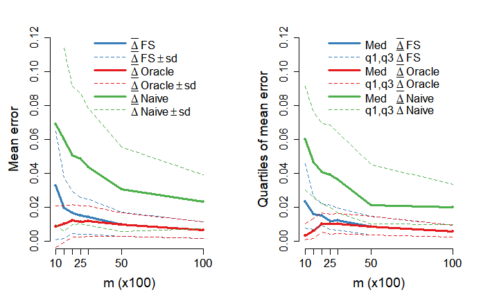

```r
 par(mfrow = c(1,2), oma = c(0,0,0,0))

 ## --- Left panel: Mean error with standard deviation bands ---
 par(mar = c(5,5,3,4), xpd = NA)

 plot(m/100, Fmean, type = "l", col = "#377EB8",
      xlab = "m (x100)", ylab = "Mean error", ylim = c(0, 0.12), lwd = 3,
      frame.plot = FALSE, xaxt = "n", yaxt = "n", xlim = c(10,100),
      cex.axis = 1.4, cex.lab = 1.6)
 lines(m/100, Omean, col = "#E41A1C", lwd = 3)
 lines(m/100, Nmean, col = "#4DAF4A", lwd = 3)
 points(m/100, Fmean, col = "#377EB8", pch = 19, cex = 0.7)
 points(m/100, Omean, col = "#E41A1C", pch = 19, cex = 0.7)
 points(m/100, Nmean, col = "#4DAF4A", pch = 19, cex = 0.7)
 lines(m/100, FsdUp, col = "#377EB8", lty = 2)
 lines(m/100, FsdLo, col = "#377EB8", lty = 2)
 lines(m/100, OsdUp, col = "#E41A1C", lty = 2)
 lines(m/100, OsdLo, col = "#E41A1C", lty = 2)
 cap <- 0.12
 NsdUp_cut <- ifelse(NsdUp > cap, NA, NsdUp)
 lines(m/100, NsdUp_cut, col = "#4DAF4A", lty = 2)
 lines(m/100, NsdLo, col = "#4DAF4A", lty = 2)
 axis(side = 1, at = m/100, labels = m/100, cex.axis = 1.4)
 axis(side = 2, cex.axis = 1.4)

 legend(
   "topright",
   inset = c(0.05, 0),
   legend = c(expression(bar(Delta) ~ "FS"),
              expression(bar(Delta) ~ "FS" %+-% "sd"),
              expression(bar(Delta) ~ "Oracle"),
              expression(bar(Delta) ~ "Oracle" %+-% "sd"),
              expression(bar(Delta) ~ "Naive"),
              expression(bar(Delta) ~ "Naive" %+-% "sd")),
   col = c("#377EB8","#377EB8","#E41A1C","#E41A1C","#4DAF4A","#4DAF4A"),
   lty = c(1,2,1,2,1,2),
   lwd = c(3,1.5,3,1.5,3,1.5), bty = "n",
   y.intersp = 0.95, x.intersp = 0.5, seg.len = 3, cex = 1.4
 )

 ## --- Right panel: Median and quartiles ---
 par(mar = c(5,5,3,4), xpd = NA)

 plot(m/100, Fq2, type = "l", col = "#377EB8",
      xlab = "m (x100)", ylab = "Quartiles of mean error",
      ylim = c(0, 0.12), lwd = 3, frame.plot = FALSE, xaxt = "n", yaxt = "n",
      xlim = c(10,100), cex.axis = 1.4, cex.lab = 1.6)
 lines(m/100, Oq2, col = "#E41A1C", lwd = 3)
 lines(m/100, Nq2, col = "#4DAF4A", lwd = 3)
 points(m/100, Fq2, col = "#377EB8", pch = 19, cex = 0.7)
 points(m/100, Oq2, col = "#E41A1C", pch = 19, cex = 0.7)
 points(m/100, Nq2, col = "#4DAF4A", pch = 19, cex = 0.7)
 lines(m/100, Fq1, col = "#377EB8", lty = 2)
 lines(m/100, Fq3, col = "#377EB8", lty = 2)
 lines(m/100, Oq1, col = "#E41A1C", lty = 2)
 lines(m/100, Oq3, col = "#E41A1C", lty = 2)
 lines(m/100, Nq1, col = "#4DAF4A", lty = 2)
 lines(m/100, Nq3, col = "#4DAF4A", lty = 2)
 axis(side = 1, at = m/100, labels = m/100, cex.axis = 1.4)
 axis(side = 2, cex.axis = 1.4)

 legend(
   "topright",
   inset = c(0.09, 0),
   legend = c(expression("Med  " ~ bar(Delta) ~ "FS"),
              expression("q1,q3" ~ bar(Delta) ~ "FS"),
              expression("Med  " ~ bar(Delta) ~ "Oracle"),
              expression("q1,q3" ~ bar(Delta) ~ "Oracle"),
              expression("Med  " ~ bar(Delta) ~ "Naive"),
              expression("q1,q3" ~ bar(Delta) ~ "Naive")),
   col = c("#377EB8","#377EB8","#E41A1C","#E41A1C","#4DAF4A","#4DAF4A"),
   lty = c(1,2,1,2,1,2),
   lwd = c(3,1.5,3,1.5,3,1.5), bty = "n",
   y.intersp = 0.95, x.intersp = 0.5, seg.len = 3, cex = 1.4
 )
```

### 5.4 Analysis of Real-World Data

```r
data("tempdata")
```

1. Treat NA data:

Removing days before “2010-08-05”

```r
tempdata <- hdMTD::tempdata %>% filter(DATE >= "2010-08-05")
```

Identify remaining \(155\) NA positions

```r
posNA <- which(is.na(tempdata$MAXTEMP))
```

Fill short sequences of NAs ( \(≤6\) NAs) using nearest neighbors mean

```r
for (i in posNA) {
  if(!is.na(tempdata$MAXTEMP[i - 1]) && !all(is.na(tempdata$MAXTEMP[(i + 1):(i + 6)]))) {
    aux <- which(!is.na(tempdata$MAXTEMP[(i + 1):(i + 6)]))[1]
    tempdata$MAXTEMP[i] <- mean(tempdata$MAXTEMP[i - 1],tempdata$MAXTEMP[i + aux])
  }
}
```

Identify remaining \(88\) NA positions

```r
posNA <- which(is.na(tempdata$MAXTEMP))
```

Fill remaining NA with the mean of the previous hour temperature, next hour temperature, and same hour of previous day temperature.

```r
for (i in posNA) {
  tempdata$MAXTEMP[i] <- mean(c(tempdata$MAXTEMP[i - 1], tempdata$MAXTEMP[i + 1],
                                tempdata$MAXTEMP[i - 24]),na.rm = TRUE)
}
```

2. Compute mean daily maximum temperatures:

```r
temp <- tempdata %>%
  group_by(DATE) %>%
  summarize(MAXTEMP = mean(MAXTEMP), .groups = 'drop')
head(temp, 4)
```

```
## # A tibble: 4 × 2
##   DATE       MAXTEMP
##   <date>       <dbl>
## 1 2010-08-05    20.7
## 2 2010-08-06    20.5
## 3 2010-08-07    21.8
## 4 2010-08-08    22.3
```

### Plot Figure 2: Time series with quarterly mean of daily maximum temperatures

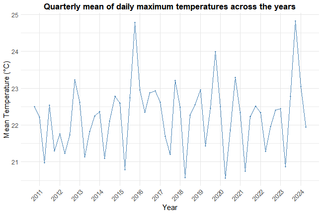

```r
 TRIM_DATA <- temp %>%
   mutate(
     Y_TRIMESTER = paste0(year(DATE), "-T", quarter(DATE))
   ) %>%
   group_by(Y_TRIMESTER) %>%
   summarise(
     MEAN_TEMP = mean(MAXTEMP),
     DATA_REF = min(DATE)
   ) %>%
   ungroup() %>%
   arrange(DATA_REF)
 TRIM_DATA <- TRIM_DATA[-c(1, nrow(TRIM_DATA)),]

 ggplot(TRIM_DATA, aes(x = DATA_REF, y = MEAN_TEMP)) +
   geom_line(color = "steelblue", linewidth = 0.5) +
   geom_point(color = "steelblue", size = 1.2) +
   scale_x_date(
     date_breaks = "1 year",
     date_labels = "%Y",
     minor_breaks = NULL
   ) +
   theme_minimal() +
   theme(
     axis.text.x = element_text(angle = 45, hjust = 1, size = 12),
     axis.text.y = element_text(size = 12),
     panel.grid.major = element_line(color = "gray90"),
     axis.title.x = element_text(size = 15),
     axis.title.y = element_text(size = 15),
     plot.title = element_text(hjust = 0.5, size = 17, face = "bold")
   ) +
   labs(
     title = "Quarterly mean of daily maximum temperatures across the years",
     x = "Year",
     y = "Mean Temperature (°C)"
   )
```

3. Create categories of temperature:

```r
xn <- max(temp$MAXTEMP)
x1 <- min(temp$MAXTEMP)
maxAmp <- xn - x1
temp$MAXTEMP1  <- ifelse(temp$MAXTEMP < x1 + maxAmp/2, 1, 2)
head(temp, 4)
```

```
## # A tibble: 4 × 3
##   DATE       MAXTEMP MAXTEMP1
##   <date>       <dbl>    <dbl>
## 1 2010-08-05    20.7        1
## 2 2010-08-06    20.5        1
## 3 2010-08-07    21.8        2
## 4 2010-08-08    22.3        2
```

```r
prop.table(table(temp$MAXTEMP1)) # frequency of thermal regimes
```

```
##
##         1         2
## 0.2606497 0.7393503
```

4. Run FS for temp:

```r
Temp12 <- rev(temp$MAXTEMP1)
```

hdMTD functions assume the sample is sorted from the latest observations to oldest.

```r
recompute <- FALSE
recompute <- recompute || (!use_precomputed_hdMTD_outputs)
```

```r
if (recompute) {
  message("Recomputing...")
  FS_Temp12_d400 <- hdMTD_FS(Temp12, d = 400, l = 3) #takes ~7min.
  precomputed$FS_Temp12_d400 <- FS_Temp12_d400
} else {
  message("Using pre-computed data.")
  FS_Temp12_d400 <- precomputed$FS_Temp12_d400
}
```

```
## Recomputing...
```

```r
print(FS_Temp12_d400)
```

```
## [1]   1 364   6
```

Note: The next code line is mentioned in the article but without a CodeChunk  
Reduce maximum order to improve estimation

```r
recompute <- FALSE
recompute <- recompute || (!use_precomputed_hdMTD_outputs)
```

```r
if (recompute) {
  message("Recomputing...")
  FS_Temp12_d364 <- hdMTD_FS(Temp12, d = 364, l = 3) #takes ~6min.
  precomputed$FS_Temp12_d364 <- FS_Temp12_d364
} else {
  message("Using pre-computed data.")
  FS_Temp12_d364 <- precomputed$FS_Temp12_d364
}
```

```
## Recomputing...
```

```r
print(FS_Temp12_d364)
```

```
## [1]   1 364   6
```

5. Split sample in Train and Test data:

```r
ndays <- nrow(temp %>%
                filter(DATE >= "2023-09-01")) # 366 days in the latest year of the sample
Temp12_Train <- Temp12[-seq_len(ndays)] # Training data with 4775 days
Temp12_Test <- Temp12[seq_len(ndays)] # Test data
```

6. Rerun FS for Train data:

```r
recompute <- FALSE
recompute <- recompute || (!use_precomputed_hdMTD_outputs)
```

```r
if (recompute) {
  message("Recomputing...")
  FS_Temp12Train <- hdMTD_FS(Temp12_Train, d = 364, l = 3) #takes ~5min.
  precomputed$FS_Temp12Train <- FS_Temp12Train
} else {
  message("Using pre-computed data.")
  FS_Temp12Train <- precomputed$FS_Temp12Train
}
```

```
## Recomputing...
```

```r
print(FS_Temp12Train)
```

```
## [1]   1 364   6
```

7. Trim out irrelevant lags:

With CUT method

```r
hdMTD_CUT(Temp12_Train, d = 364, S = c(1, 364, 6))
```

```
## [1]   1   6 364
```

With BIC method

```r
hdMTD_BIC(Temp12_Train, d = 364, S = c(1, 364, 6), minl = 1, maxl = 3,
          byl = TRUE, BICvalue = TRUE )
```

```
##                 1             1,364           1,6,364 smallest: 1,6,364
##          1720.801          1690.543          1674.080          1674.080
```

8. Estimated transition matrix for FS method output:

```r
P_FS <- empirical_probs(Temp12_Train, S = c(1, 6, 364), matrixform = T)
P_FS
```

```
##              1         2
## 111 0.86626140 0.1337386
## 112 0.24736842 0.7526316
## 121 0.77157360 0.2284264
## 122 0.13318777 0.8668122
## 211 0.78846154 0.2115385
## 212 0.10972569 0.8902743
## 221 0.57506361 0.4249364
## 222 0.07283555 0.9271645
```

### Classic method for choosing relevant lag set:

9. Compute models:

```r
ct <- countsTab(Temp12_Train, d = 6) # Table with size 6 sequence counts
head(ct,4)
```

```
## # A tibble: 4 × 8
##      x6    x5    x4    x3    x2    x1     a   Nxa
##   <dbl> <dbl> <dbl> <dbl> <dbl> <dbl> <dbl> <int>
## 1     1     1     1     1     1     1     1   342
## 2     1     1     1     1     1     1     2    62
## 3     1     1     1     1     1     2     1    18
## 4     1     1     1     1     1     2     2    62
```

MC1 (does not explicitly appear in the article)

```r
ft <- freqTab(S = 1, A = c(1, 2), countsTab = ct)
LL <- sum(log(ft$qax_Sj) * ft$Nxa_Sj)
freeParam <- 2 * 1
BICMC1 <- -LL + 0.5 * log(length(Temp12_Train)) * freeParam
BICMC1
```

```
## [1] 1869.162
```

Comparable BIC if the model is a Markov chain of order \(1\): \(1869.162\)

MC2 (does not explicitly appear in the article)

```r
ft <- freqTab(S = c(1, 2), A = c(1, 2), countsTab = ct)
LL <- sum(log(ft$qax_Sj) * ft$Nxa_Sj)
freeParam <- 2^2 * 1
BICMC2 <- -LL + 0.5 * log(length(Temp12_Train)) * freeParam
BICMC2
```

```
## [1] 1850.598
```

Comparable BIC if the model is a Markov chain of order \(2\): \(1850.598\)

MC3. Used as example in the article

```r
ft <- freqTab(S = c(1, 2, 3), A = c(1, 2), countsTab = ct)
head(ft, 4)
```

```
## # A tibble: 4 × 7
##      x3    x2    x1     a Nxa_Sj Nx_Sj qax_Sj
##   <dbl> <dbl> <dbl> <dbl>  <int> <int>  <dbl>
## 1     1     1     1     1    587   726  0.809
## 2     1     1     1     2    139   726  0.191
## 3     1     1     2     1     38   206  0.184
## 4     1     1     2     2    168   206  0.816
```

```r
LL <- sum(log(ft$qax_Sj) * ft$Nxa_Sj)
freeParam <- 2^3 * 1
BICMC3 <- -LL + 0.5 * log(length(Temp12_Train)) * freeParam
BICMC3
```

```
## [1] 1854.029
```

Comparable BIC if the model is a Markov chain of order \(3\): \(1854.029\)

MC4 (does not explicitly appear in the article)

```r
ft <- freqTab(S = c(1, 2, 3, 4), A = c(1, 2), countsTab = ct)
LL <- sum(log(ft$qax_Sj) * ft$Nxa_Sj)
freeParam <- 2^4 * 1
BICMC4 <- -LL + 0.5 * log(length(Temp12_Train)) * freeParam
BICMC4
```

```
## [1] 1877.888
```

Comparable BIC if the model is a Markov chain of order \(4\): \(1877.888\)

MC5 (does not explicitly appear in the article)

```r
ft <- freqTab(S = c(1, 2, 3, 4, 5), A = c(1, 2), countsTab = ct)
pos <- which(ft$Nxa_Sj > 0)
LL <- sum(log(ft$qax_Sj[pos]) * ft$Nxa_Sj[pos])
freeParam <- 2^5 * 1
BICMC5 <- -LL + 0.5 * log(length(Temp12_Train)) * freeParam
BICMC5
```

```
## [1] 1925.962
```

Comparable BIC if the model is a Markov chain of order \(5\): \(1925.962\)

MC6 (does not explicitly appear in the article)

```r
ft <- freqTab(S = c(1, 2, 3, 4, 5, 6), A = c(1, 2), countsTab = ct)
pos <- which(ft$Nxa_Sj > 0)
LL <- sum(log(ft$qax_Sj[pos]) * ft$Nxa_Sj[pos])
freeParam <- 2^6 * 1
BICMC6 <- -LL + 0.5 * log(length(Temp12_Train)) * freeParam
BICMC6
```

```
## [1] 2031.679
```

Comparable BIC if the model is a Markov chain of order \(6\): \(2031.679\)

10. Comparing models:

```r
BIC_vals <-  c(BICMC1, BICMC2, BICMC3, BICMC4, BICMC5, BICMC6)
model_names <- paste0("MC", 1:6)
minBIC_idx <- which.min(BIC_vals)
BIC_fmt <- sprintf("%.3f", BIC_vals)
BIC_fmt[minBIC_idx] <- paste0("**", BIC_fmt[minBIC_idx], "**")
minBIC_idx
```

```
## [1] 2
```

The classic method chooses order \(2\) (\(S=\{-2,-1\}\)).

Generating BIC values Table

```r
bic_matrix <- data.frame(matrix(BIC_fmt, nrow = 1))
colnames(bic_matrix) <- model_names
rownames(bic_matrix) <- "BIC"
```

Table 2: BIC values

```r
tbl_2 <- suppressWarnings(
  knitr::kable(
    bic_matrix,
    caption = "BIC values computed for classical Markov chain models of different orders."
  )
)
suppressWarnings(print(tbl_2))
```

Table: BIC values computed for classical Markov chain models of different orders.

|  | MC1 | MC2 | MC3 | MC4 | MC5 | MC6 |
| --- | --- | --- | --- | --- | --- | --- |
| BIC | 1869.162 | **1850.598** | 1854.029 | 1877.888 | 1925.962 | 2031.679 |

Estimated matrix for \(S=\{-2,-1\}\)

```r
P_MC2 <- empirical_probs(Temp12_Train, S = c(1, 2), matrixform = TRUE)
P_MC2
```

```
##             1         2
## 11 0.77813505 0.2218650
## 12 0.16326531 0.8367347
## 21 0.60233918 0.3976608
## 22 0.09064976 0.9093502
```

Independent model distribution:

```r
P_Ind <- prop.table(table(Temp12_Train))
P_Ind
```

```
## Temp12_Train
##         1         2
## 0.2672251 0.7327749
```

### Comparing methods

11. Computing values for Table 3.

```r
Days1 <- which(Temp12_Test == 1)
lenDays1 <- length(Days1)
lenDays1 / ndays # frequency of low temperature days
```

```
## [1] 0.1748634
```

```r
Temp12_Test <- c(Temp12_Test, Temp12_Train[seq_len(364)])
```

```r
set.seed(1)
hitInd <- numeric(1000)
hitMC2 <- numeric(1000)
hitFS <- numeric(1000)
T1Ind <- numeric(1000)
T1MC2 <- numeric(1000)
T1FS <- numeric(1000)
F1Ind <- numeric(1000)
F1MC2 <- numeric(1000)
F1FS <- numeric(1000)
pasts2 <- rownames(P_MC2)
pastsFS <- rownames(P_FS)
```

```r
for (j in seq_len(1000)){
  u <- runif(ndays)
  predInd <- numeric(ndays)
  predMC2 <- numeric(ndays)
  predFS <- numeric(ndays)

  for (i in ndays:1) {
    predInd[i] <- ifelse(u[i] <= P_Ind[1], 1, 2)
    pastRow <- which(pasts2 == paste0(rev(Temp12_Test[c(i+1, i+2)]), collapse = ""))
    predMC2[i] <- ifelse(u[i] <= P_MC2[pastRow, 1], 1, 2)
    pastRow <- which(pastsFS == paste0(rev(Temp12_Test[c(i+1, i+6, i+364)]), collapse = ""))
    predFS[i] <- ifelse(u[i] <= P_FS[pastRow, 1], 1, 2)
  }

  hitInd[j] <- sum(predInd == Temp12_Test[seq_len(ndays)])
  hitMC2[j] <- sum(predMC2 == Temp12_Test[seq_len(ndays)])
  hitFS[j] <- sum(predFS == Temp12_Test[seq_len(ndays)])
  T1Ind[j] <- sum(predInd[Days1] == 1)
  T1MC2[j] <- sum(predMC2[Days1] == 1)
  T1FS[j] <- sum(predFS[Days1] == 1)
  F1Ind[j] <- sum(predInd[-Days1] == 1)
  F1MC2[j] <- sum(predMC2[-Days1] == 1)
  F1FS[j] <- sum(predFS[-Days1] == 1)
}
```

### Accuracy

```r
AccInd <- mean(hitInd)/ndays
AccMC2 <- mean(hitMC2)/ndays
AccFS <- mean(hitFS)/ndays
AccInd; AccMC2; AccFS
```

```
## [1] 0.6509262
```

```
## [1] 0.8236585
```

```
## [1] 0.8349153
```

### Precision

```r
PrecInd <- mean(T1Ind/(T1Ind + F1Ind))
PrecMC2 <- mean(T1MC2/(T1MC2 + F1MC2))
PrecFS <- mean(T1FS/(T1FS + F1FS))
PrecInd; PrecMC2; PrecFS
```

```
## [1] 0.1745824
```

```
## [1] 0.4981026
```

```
## [1] 0.5249133
```

### Sensitivity (Recall)

```r
SensInd <- mean(T1Ind)/lenDays1
SensMC2 <- mean(T1MC2)/lenDays1
SensFS <- mean(T1FS)/lenDays1
SensInd; SensMC2; SensFS
```

```
## [1] 0.2671875
```

```
## [1] 0.5870313
```

```
## [1] 0.6294531
```

### Specificity

```r
SpecInd <- 1 - mean(F1Ind)/(ndays - lenDays1)
SpecMC2 <- 1 - mean(F1MC2)/(ndays - lenDays1)
SpecFS <- 1 - mean(F1FS)/(ndays - lenDays1)
SpecInd; SpecMC2; SpecFS
```

```
## [1] 0.7322483
```

```
## [1] 0.8738046
```

```
## [1] 0.878457
```

### F1-Score

```r
F1ScoreInd <- 2 * (PrecInd * SensInd) / (PrecInd + SensInd)
F1ScoreMC2 <- 2 * (PrecMC2 * SensMC2) / (PrecMC2 + SensMC2)
F1ScoreFS <- 2 * (PrecFS * SensFS) / (PrecFS + SensFS)
F1ScoreInd; F1ScoreMC2; F1ScoreFS
```

```
## [1] 0.2111789
```

```
## [1] 0.538923
```

```
## [1] 0.5724496
```

```r
metric <- c("Accuracy", "Precision", "Sensitivity (Recall)", "Specificity", "F1-Score")
formula <- c("(TP+TN)/(TP+TN+FP+FN)",
             "TP/(TP+FP)",
             "TP/(TP+FN)",
             "TN/(TN+FP)",
             "2(PPV*Recall)/(PPV+Recall)")
performance_table <- data.frame(
  Metric = metric,
  Formula = formula,
  indc = round(c(AccInd, PrecInd, SensInd, SpecInd, F1ScoreInd) * 100, 2),
  mc2c = round(c(AccMC2, PrecMC2, SensMC2, SpecMC2, F1ScoreMC2) * 100, 2),
  fsc = round(c(AccFS, PrecFS, SensFS, SpecFS, F1ScoreFS) * 100, 2),
  check.names = FALSE
)
names(performance_table) <- c("Metric", "Formula", "Ind (\\%)", "MC2 (\\%)", "FS (\\%)")
```

Table 3: Model performance metrics

```r
suppressWarnings(
  tbl_3 <- knitr::kable(performance_table, align = "l",
                        caption = "Model performance metrics.")
)
suppressWarnings(print(tbl_3))
```

Table: Model performance metrics.

| Metric | Formula | Ind (%) | MC2 (%) | FS (%) |
| --- | --- | --- | --- | --- |
| Accuracy | (TP+TN)/(TP+TN+FP+FN) | 65.09 | 82.37 | 83.49 |
| Precision | TP/(TP+FP) | 17.46 | 49.81 | 52.49 |
| Sensitivity (Recall) | TP/(TP+FN) | 26.72 | 58.70 | 62.95 |
| Specificity | TN/(TN+FP) | 73.22 | 87.38 | 87.85 |
| F1-Score | 2(PPV*Recall)/(PPV+Recall) | 21.12 | 53.89 | 57.24 |

### Plot Figure 3: Exploratory analysis of accuracies

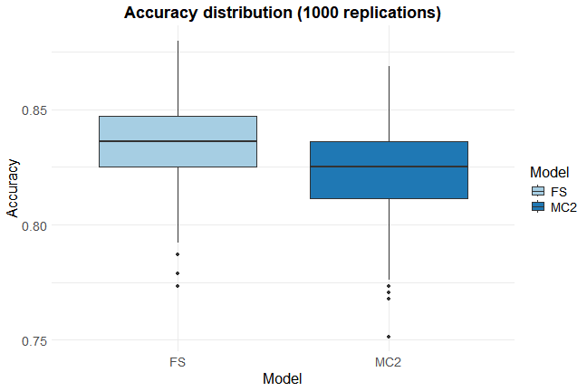

```r
 accuracy_data <- data.frame(
   MC2 = hitMC2 / ndays,
   FS = hitFS / ndays
 ) %>%
   pivot_longer(
     everything(),
     names_to = "Model",
     values_to = "Accuracy"
   )

 ggplot(accuracy_data, aes(x = Model, y = Accuracy, fill = Model)) +
   geom_boxplot() +
   labs(
     title = "Accuracy distribution (1000 replications)",
     x = "Model",
     y = "Accuracy"
   ) +
   theme_minimal() +
   scale_fill_brewer(palette = "Paired") +
   theme(
     plot.title = element_text(hjust = 0.5, size = 18, face = "bold"),
     axis.title = element_text(size = 16),
     axis.text = element_text(size = 14),
     legend.title = element_text(size = 16),
     legend.text = element_text(size = 14)
   )
```

### Empirical \(\nu\) Analysis

12. FS sequential selection based on \(\hat{\nu}_{n,j,S}\) values:

```r
run_sequential_lag_selection <- function(Temp12_Train, d = 364) {
  # Initialization
  A <-  sort(unique(Temp12_Train))
  lenA <- length(A)
  lenX <- length(Temp12_Train)
  A_pairs <- matrix(A, ncol = 2) # All unique state pairs
  ct <- countsTab(X = Temp12_Train, d = 364) # Sequence counts table

  # Initialize storage
  results <- list(
    nuj1 = numeric(d),
    nuj2 = numeric(d-1),
    nuj3 = numeric(d-2),
    selected_lags = numeric(3)
  )

  # Helper function for empirical distribution calculation
  PI <- function(S, groupTab, x_S, lenX, d) {
    if (length(S) > 0) {
      filtr_S <- paste0("x", S)
      groupTab <- groupTab %>%
        dplyr::mutate(match = purrr::pmap_lgl(dplyr::pick(dplyr::all_of(filtr_S)),
                                              ~ all(c(...) == x_S))) %>%
        dplyr::filter(match) %>%
        dplyr::select(-match)
    }
    PI <- matrix(groupTab$Nx_Sj/(lenX - d),ncol = 1)
    PI
  }

  # Sequential Selection Process
  cat("=== Starting Sequential Lag Selection ===\n")

  # Step 1: Initial selection (S = ∅)
  cat("\n[Step 1] Selecting first lag (S = ∅)...\n")
  S <- NULL
  Sc <- sort(setdiff(seq_len(d), S), decreasing = TRUE) # Complement of S in 1:d

  for (z in seq_along(Sc)) { # Runs across all available lags
    j <- Sc[z]
    # Frequency tables
    b_Sja <- freqTab(S = S, j = j, A = A, countsTab = ct)
    b_Sj <- b_Sja %>%
      dplyr::group_by(dplyr::across(dplyr::all_of(paste0("x", j)))) %>%
      dplyr::summarise(Nx_Sj = sum(Nxa_Sj), .groups = "drop")

    # Compute νj
    PIs <- PI(S = S, groupTab = b_Sj, x_S = S, lenX = lenX, d = 364)
    dTVs <- dTV_sample(S = S, j = j, lenA = lenA, base = b_Sja,
                       A_pairs = A_pairs, x_S = S)
    results$nuj1[z] <- prod(PIs) * dTVs
  }
  results$selected_lags[1] <- Sc[which.max(results$nuj1)]
  cat(sprintf("Selected: j = %d (ν = %.4f)\n",
              results$selected_lags[1], max(results$nuj1)))

  # Step 2: Second selection (S = {1})
  cat(sprintf("\n[Step 2] Selecting second lag (S = {%d})...\n",
              results$selected_lags[1]))
  S <- results$selected_lags[1]
  Sc <- sort(setdiff(seq_len(d), S), decreasing = TRUE)

  for (z in seq_along(Sc)) {
    j <- Sc[z]
    Sj <- sort(c(S, j), decreasing = TRUE)

    # Frequency tables
    b_Sja <- freqTab(S = S, j = j, A = A, countsTab = ct)
    b_Sj <- b_Sja %>%
      dplyr::group_by(dplyr::across(dplyr::all_of(paste0("x", Sj)))) %>%
      dplyr::summarise(Nx_Sj = sum(Nxa_Sj), .groups = "drop")
    b_S <- b_Sja %>%
      dplyr::group_by(dplyr::across(dplyr::all_of(paste0("x", S)))) %>%
      dplyr::summarise(Nx_Sj = sum(Nxa_Sj), .groups = "drop")

    subx <- b_S[, -ncol(b_S)]

    # Compute ν_j
    for (t in which(b_S$Nx_Sj > 0)) {
      PIs <- PI(S = S, groupTab = b_Sj, x_S = subx[t, ],
                lenX = lenX, d = d)
      dTVs <- dTV_sample(S = S, j = j, lenA = lenA, base = b_Sja,
                         A_pairs = A_pairs, x_S = subx[t, ])
      PI_xS <- as.numeric(b_S[t, ncol(b_S)]/(lenX - d))
      results$nuj2[z] <- results$nuj2[z] + prod(PIs) * dTVs/PI_xS
    }
  }
  results$selected_lags[2] <- Sc[which.max(results$nuj2)]
  cat(sprintf("Selected: j = %d (ν = %.4f)\n",
              results$selected_lags[2], max(results$nuj2)))

  # Step 3: Third selection (S = {1,364})
  cat(sprintf("\n[Step 3] Selecting third lag (S = {%d,%d})...\n",
              results$selected_lags[1], results$selected_lags[2]))
  S <- c(S, results$selected_lags[2])
  Sc <- sort(setdiff(seq_len(d), S), decreasing = TRUE)

  for (z in seq_along(Sc)) {
    j <- Sc[z]
    Sj <- sort(c(S, j), decreasing = TRUE)
    dec_S <- rev(S) # S in decreasing order

    # Frequency tables
    b_Sja <- freqTab(S = dec_S, j = j, A = A, countsTab = ct)
    b_Sj <- b_Sja %>%
      dplyr::group_by(dplyr::across(dplyr::all_of(paste0("x", Sj)))) %>%
      dplyr::summarise(Nx_Sj = sum(Nxa_Sj), .groups = "drop")
    b_S <- b_Sja %>%
      dplyr::group_by(dplyr::across(dplyr::all_of(paste0("x", dec_S)))) %>%
      dplyr::summarise(Nx_Sj = sum(Nxa_Sj), .groups = "drop")

    subx <- b_S[, -ncol(b_S)]

    # Compute ν_j
    for (t in which(b_S$Nx_Sj > 0)) {
      PIs <- PI(S = dec_S, groupTab = b_Sj, x_S = subx[t, ],
                lenX = lenX, d = d)
      dTVs <- dTV_sample(S = dec_S, j = j, lenA = lenA, base = b_Sja,
                         A_pairs = A_pairs, x_S = subx[t, ])
      PI_xS <- as.numeric(b_S[t, ncol(b_S)]/(lenX - d))
      results$nuj3[z] <- results$nuj3[z] + prod(PIs) * dTVs/PI_xS
    }
  }
  results$selected_lags[3] <- Sc[which.max(results$nuj3)]
  cat(sprintf("Selected: j = %d (ν = %.4f)\n",
              results$selected_lags[3], max(results$nuj3)))

  # Final Results
  cat("\n=== Final Selection Results ===\n")
  print(data.frame(Step = 1:3, Selected_Lag = results$selected_lags,
                   nu = c(max(results$nuj1), max(results$nuj2), max(results$nuj3))))

  return(results)
}
```

```r
## Load pre-computed results of sequential selection if available and recompute_all = FALSE.
use_results_sequential <- !recompute_all && file.exists("results_sequential_selection.rds")
```

```r
recompute <- FALSE
recompute <- recompute || (!use_results_sequential)

if (recompute) {
  message("Recomputing FS sequential selection results.")
  results <- run_sequential_lag_selection(Temp12_Train) #takes ~6 min
} else {
  message("Using pre-computed FS sequential selection results from 'results_sequential_selection.rds'.")
  results <- readRDS("results_sequential_selection.rds") # using precomputed results if available
  cat("\n=== Final Selection Results ===\n")
  print(data.frame(Step = 1:3, Selected_Lag = results$selected_lags,
                   nu = c(max(results$nuj1), max(results$nuj2), max(results$nuj3))))
}
```

```
## Recomputing FS sequential selection results.
```

```
## === Starting Sequential Lag Selection ===
##
## [Step 1] Selecting first lag (S = ∅)...
## Selected: j = 1 (ν = 0.1253)
##
## [Step 2] Selecting second lag (S = {1})...
## Selected: j = 364 (ν = 0.0216)
##
## [Step 3] Selecting third lag (S = {1,364})...
## Selected: j = 6 (ν = 0.0165)
##
## === Final Selection Results ===
##   Step Selected_Lag         nu
## 1    1            1 0.12533879
## 2    2          364 0.02162680
## 3    3            6 0.01652459
```

### Plot Figure 4: FS sequential step analysis through \(\hat{\nu}_{n,j,S}\).

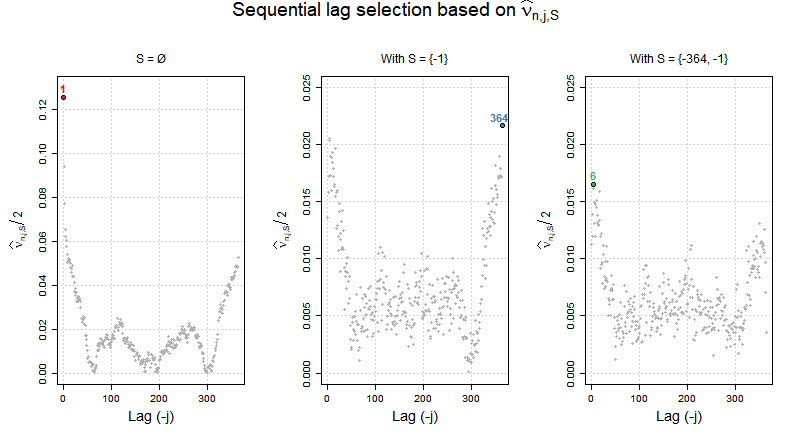

```r
 par(mfrow = c(1, 3), mar = c(5, 6, 4, 2), oma = c(0, 0, 4, 0))
 palette <- c("#E41A1C", "#377EB8", "#4DAF4A")
 with(results, {
   # Graph 1
   Sc <-  364:1
   plot(1:364, rev(nuj1), type = "p", pch = 19, cex = 0.8, col = "gray70",
        ylab = "", xlab = "Lag (-j)", cex.lab = 1.8, cex.axis = 1.3,
        ylim = c(0,0.13), main = "", panel.first = grid())
   title(main = expression(paste("S = ", Ø)), cex.main = 1.5, font.main = 1)
   title(ylab = expression(widehat(nu)[n*","*j*","*S]/2), line = 3, cex.lab = 1.5)
   points(Sc[which.max(nuj1)], nuj1[which.max(nuj1)], pch = 21, bg = palette[1], cex = 1.5, lwd = 1)
   text(Sc[which.max(nuj1)], nuj1[which.max(nuj1)], labels = paste0(Sc[which.max(nuj1)]),
        pos = 3, col = palette[1], font = 2, cex = 1.4)
   # Graph 2
   Sc <- 364:2
   plot(2:364, rev(nuj2), type = "p", pch = 19, cex = 0.8, col = "gray70",
        ylab = "", xlab = "Lag (-j)", cex.lab = 1.8, cex.axis = 1.3,
        ylim = c(0,0.025),  main = "", panel.first = grid())
   title(main = "With S = {-1}", cex.main = 1.5, font.main = 1)
   title(ylab = expression(widehat(nu)[n*","*j*","*S]/2), line = 3, cex.lab = 1.5)
   points(Sc[which.max(nuj2)], nuj2[which.max(nuj2)], pch = 21, bg = palette[2], cex = 1.5, lwd = 1)
   text(Sc[which.max(nuj2)]-5, nuj2[which.max(nuj2)], labels = paste0(Sc[which.max(nuj2)]),
        pos = 3, col = palette[2], font = 2, cex = 1.4)
   # Graph 3
   Sc <- 363:2
   plot(2:363, rev(nuj3), type = "p", pch = 19, cex = 0.8, col = "gray70",
        ylab = "", xlab = "Lag (-j)", cex.lab = 1.8, cex.axis = 1.3,
        ylim = c(0,0.025), main = "", panel.first = grid())
   title(main = "With S = {-364, -1}", cex.main = 1.5, font.main = 1)
   title(ylab = expression(widehat(nu)[n*","*j*","*S]/2), line = 3, cex.lab = 1.5)
   points(Sc[which.max(nuj3)], nuj3[which.max(nuj3)], pch = 21, bg = palette[3], cex = 1.5, lwd = 1)
   text(Sc[which.max(nuj3)], nuj3[which.max(nuj3)], labels = paste0(Sc[which.max(nuj3)]),
        pos = 3, col = palette[3], font = 2, cex = 1.4)

   mtext(expression(paste("Sequential lag selection based on ", widehat(nu)[n*","*j*","*S])),
         outer = TRUE, cex = 1.6, font = 2, line = 1.4)
 })
```

```r
if (save_precomputed) {
  message("Saving pre-computed results to 'hdMTD_outputs.rds'.")
  saveRDS(precomputed, "hdMTD_outputs.rds")
  message("Saving simulated data to 'simulated_data.rds'.")
  saveRDS(simulated_data, "simulated_data.rds")
  message("Saving FS sequential selection results to 'results_sequential_selection.rds'.")
  saveRDS(results, "results_sequential_selection.rds")
}
```